# The Ronaldo Effect !!!

## Project Overview

Since 2013, Manchester United football club has endured a terrible decade. The club's management has decided to undertake some significant changes. A new manager who is to be appointed must tailor his tactics according to the team's past performance. These strategies include recruiting, game-planning, instructing the players, and rooster management.

As Soccer has already burgeoned to become one of the most followed sports in the world, we wish to analyze the historical data of the Premier League(an English Soccer league system):

- Manchester United is one of the greatest soccer clubs in the history of the sport that competes in the Premier League. The club currently holds the record for winning 13 Premier League titles.
- Cristiano Ronaldo is a Portuguese soccer player who plays for Manchester United and currently holds the record for the most number of goals scored in the world.

As a group of data analysts appointed by the management group, we aim to help the new manager make decisions using data-driven insights. Furthermore, we will be answering the below research questions to the business committee by providing data visualizations and recommendations:

1. What does the Premier League's historical data suggest about a football club's success?
2. Determine how playing matches on the home ground affect the winning probability?
3. How has Manchester United performed in the last 30 years?
4. How has Ronaldo played a significant role in the rise and fall of Manchester United?
5. How has the trajectory of Ronaldo's career been?
6. Who might replace Ronaldo when he retires?

## Milestones and Progress

Project timeline as mentioned in the proposal along with their status:

| Project Milestones | Due Date | Progress |
| --- | --- | --- |
| Literature Review and outlining scope | 10/14/2022 | Completed |
| Data mining and Web Scraping | 10/19/2022 | Completed |
| Remove discrepancies and duplicates | 10/26/2022 | Completed |
| Manage missing values and impute them based on other observations | 10/26/2022 | Completed |
| Creation of dummy variables/categorical variables | 11/2/2022 | Completed |
| Data standardization using Regex | 11/2/2022 | Completed |
| Identify Outliers or anomalies | 11/2/2022 | Completed |
| Grouping data | 11/9/2022 | Completed |
| Analysis of Variance and Correlation | 11/9/2022 | Completed |
| Feature Analysis | 11/9/2022 | Completed |

The "We Tried" team has reached all the milestones and is on track for the project!! 👍

Note: As of now, we will not be requiring Web scraping for the project.

For the next steps, we would need Manchester United data for answering the question of how has Manchester United performed in last 30 years. Also, for answering the question of Ronaldo's career trajectory and who would be potential replacement of Ronaldo, we need to analyze the players data in the LaLiga league and Premier league data. We also plan to use Data Visualizations in the next steps where we would use high charts to prepare interactive pie charts. At this point, as mentioned, we would use High Charts for plotting interactive charts but we are not sure about its integration with the Jupyter Notebook.

## Data Acquisition and Cleaning

So far, we've answered some questions namely Ronaldo's impact on Manchester United wins and determining the role of Home ground and Away ground on the team's winning. As stated in the project plan, we have done the data cleaning where we checked for duplicate values, removed discrepancies from the columns, used regex to clean the data and made it useful for further analysis. We also used categorical variables for assigning the categories of Home, Away and Draw when we were analyzing the Home & Away ground data. We also used the correlation matrix to get a correlation between Home and Away ground data with the game results. We dealt with missing values and also imputed values wherever required. We have also done feature analysis where we dropped the irrelevant columns which are not required.

```python
# Load the libraries required for the data analysis, cleaning and processing

import numpy as np
import pandas as pd
from matplotlib import pyplot as plt
import datetime as dt
import seaborn as sns
import regex as re
```

### Premier League Dataset

Premier League Matches 1993-2020: This dataset consists of all the matches in the premier league that took place from 1993 to 2020. Each season lasts for 1 year, and a total of 20 teams compete in the competition. It gives us the details about each match:

- Where it took place
- How many goals were scored
- Who won the match etc.

```python
# Load dataset for analysis

premier_league_df = pd.read_csv('Premier_League_data.csv')

# Display output printing first 5 rows

premier_league_df.head()
```

|  | Season_End_Year | Wk | Date | Home | HomeGoals | AwayGoals | Away | FTR |
| --- | --- | --- | --- | --- | --- | --- | --- | --- |
| 0 | 1993 | 1 | 1992-08-15 | Coventry City | 2 | 1 | Middlesbrough | H |
| 1 | 1993 | 1 | 1992-08-15 | Leeds United | 2 | 1 | Wimbledon | H |
| 2 | 1993 | 1 | 1992-08-15 | Sheffield Utd | 2 | 1 | Manchester Utd | H |
| 3 | 1993 | 1 | 1992-08-15 | Crystal Palace | 3 | 3 | Blackburn | D |
| 4 | 1993 | 1 | 1992-08-15 | Arsenal | 2 | 4 | Norwich City | A |

### Data Cleaning & Preparation - Premier League Dataset

In the Dataset we have "Wk" column which denotes Week, as using Week won't play a significant role in determining the home ground winner, We will not be using this column in analysis going forward, therfore we are dropping the column.

#### Drop columns

```python
# Dropping the columns from the dataset

premier_league_df = premier_league_df.drop('Wk', axis=1)

#Display output printing the first 5 rows

premier_league_df.head()
```

|  | Season_End_Year | Date | Home | HomeGoals | AwayGoals | Away | FTR |
| --- | --- | --- | --- | --- | --- | --- | --- |
| 0 | 1993 | 1992-08-15 | Coventry City | 2 | 1 | Middlesbrough | H |
| 1 | 1993 | 1992-08-15 | Leeds United | 2 | 1 | Wimbledon | H |
| 2 | 1993 | 1992-08-15 | Sheffield Utd | 2 | 1 | Manchester Utd | H |
| 3 | 1993 | 1992-08-15 | Crystal Palace | 3 | 3 | Blackburn | D |
| 4 | 1993 | 1992-08-15 | Arsenal | 2 | 4 | Norwich City | A |

#### Duplicates

```python
# Check for duplicates in the dataset

duplicates = premier_league_df.duplicated().sum()

print(f'Number of duplicates in the dataset are:{duplicates}')
```

```
Number of duplicates in the dataset are:0
```

Here, we checked for duplicated values in our dataset. When we take the sum of the booleans using duplicated function, it was found that there are no duplicates in the dataset.

#### Home ground Analysis

To determine whether a team has any benefit of playing at their home ground, first lets calculate the percentage of home ground wins for all teams in Premier League from years 1993-2020:

```python
#Total percentage of home wins in Premier League from 1993-2020

percentage = 100
total_home_percentage = len(premier_league_df[premier_league_df.FTR == 'H'])/len(premier_league_df)*percentage

print(f'Percentage of home wins in Premier League dataset from 1993-2020 is {total_home_percentage:0.2f}%')
```

```
Percentage of home wins in Premier League dataset from 1993-2020 is 45.81%
```

We have now calculated that 45.81% of team's have won on their home ground.

#### Away ground Analysis

Away wins are the games which are played on the opponent teams home ground. Lets analyze winning percentage for teams in the dataset:

```python
#Total percentage of away wins in PL from 1993-2020

total_away_percentage = len(premier_league_df[premier_league_df.FTR == 'A'])/len(premier_league_df)*percentage

print(f'Percentage of away wins in Premier League dataset from 1993-2020 is {total_away_percentage:0.2f}%')
```

```
Percentage of away wins in Premier League dataset from 1993-2020 is 28.34%
```

We have now calculated that 28.34% of Team's have won on their opponent teams home ground.

#### Home ground and Away ground Analysis for Manchester United

```python
# Filtering Manchester United home games data

manchester_united_home_games = premier_league_df[premier_league_df.Home == 'Manchester Utd']

# Display output for filtered data

manchester_united_home_games.head()
```

|  | Season_End_Year | Date | Home | HomeGoals | AwayGoals | Away | FTR |
| --- | --- | --- | --- | --- | --- | --- | --- |
| 12 | 1993 | 1992-09-26 | Manchester Utd | 0 | 0 | QPR | D |
| 42 | 1993 | 1992-10-18 | Manchester Utd | 2 | 2 | Liverpool | D |
| 57 | 1993 | 1992-10-31 | Manchester Utd | 0 | 1 | Wimbledon | A |
| 80 | 1993 | 1992-11-21 | Manchester Utd | 3 | 0 | Oldham Athletic | H |
| 108 | 1993 | 1992-12-06 | Manchester Utd | 2 | 1 | Manchester City | H |

```python
# Filtering Manchester United away games data

manchester_united_away_games = premier_league_df[premier_league_df.Away == 'Manchester Utd']

# Display output for filtered data

manchester_united_away_games.head()
```

|  | Season_End_Year | Date | Home | HomeGoals | AwayGoals | Away | FTR |
| --- | --- | --- | --- | --- | --- | --- | --- |
| 2 | 1993 | 1992-08-15 | Sheffield Utd | 2 | 1 | Manchester Utd | H |
| 23 | 1993 | 1992-10-03 | Middlesbrough | 1 | 1 | Manchester Utd | D |
| 45 | 1993 | 1992-10-24 | Blackburn | 0 | 0 | Manchester Utd | D |
| 74 | 1993 | 1992-11-07 | Aston Villa | 1 | 0 | Manchester Utd | H |
| 90 | 1993 | 1992-11-28 | Arsenal | 0 | 1 | Manchester Utd | A |

Let us now calculate all the win/draw/lost percentages for Manchester United football club for both home and away games:

```python
# Manchester United's win percentage at home games

manchester_united_home_win_per = (len(manchester_united_home_games[manchester_united_home_games['FTR'] == 'H'])/len(manchester_united_home_games))*percentage
print(f'Manchester Uniteds win percentage at home games: {manchester_united_home_win_per:.2f}%')

# Manchester United's draw percentage at home games

manchester_united_home_draw_per = len(manchester_united_home_games[manchester_united_home_games['FTR'] == 'D'])/len(manchester_united_home_games)*percentage
print(f'Manchester Uniteds draw percentage at home games: {manchester_united_home_draw_per:.2f}%')

# Manchester United's lost percentage at home games

manchester_united_home_lost_per = len(manchester_united_home_games[manchester_united_home_games['FTR'] == 'A'])/len(manchester_united_home_games)*percentage
print(f'Manchester Uniteds lost percentage at home games: {manchester_united_home_lost_per:.2f}%')

# Manchester United's lost percentage at away games

manchester_united_away_lost_per = len(manchester_united_away_games[manchester_united_away_games['FTR'] == 'H'])/len(manchester_united_away_games)*percentage
print(f'Manchester Uniteds lost percentage at away games: {manchester_united_away_lost_per:.2f}%')

# Manchester United's draw percentage at away games

manchester_united_away_draw_per = len(manchester_united_away_games[manchester_united_away_games['FTR'] == 'D'])/len(manchester_united_away_games)*percentage
print(f'Manchester Uniteds draw percentage at away games: {manchester_united_away_draw_per:.2f}%')

# Manchester United's win percentage at away games

manchester_united_away_win_per = len(manchester_united_away_games[manchester_united_away_games['FTR'] == 'A'])/len(manchester_united_away_games)*percentage
print(f'Manchester Uniteds win percentage at away games: {manchester_united_away_win_per:.2f}%')
```

```
Manchester Uniteds win percentage at home games: 69.79%
Manchester Uniteds draw percentage at home games: 19.10%
Manchester Uniteds lost percentage at home games: 11.11%
Manchester Uniteds lost percentage at away games: 22.22%
Manchester Uniteds draw percentage at away games: 25.52%
Manchester Uniteds win percentage at away games: 52.26%
```

#### Full Time Result

FTR column denotes the "Full Time Result" which determines the result of the match. It has values like H, A, D. The explaination for values are as follows:

- H indicates home ground team won
- A indicates away ground team won
- D indicates Draw happened between teams

For our analysis lets assign numerical values to the alphabets:

- H is assigned to 1
- D is assigned to 0
- A is assigned to -1

```python
# Converting FTR column to integer data type for correlation

int_FTR = {'H':1,'D':0,'A':-1}
manchester_united_home_games['int_FTR'] = manchester_united_home_games.FTR.map(int_FTR)
manchester_united_away_games['int_FTR'] = manchester_united_away_games.FTR.map(int_FTR)
```

#### Correlation - Game Results and Home ground

Let's create a correlation matrix to determine if their is any correlation between Game Results and Home goals. This will help us understand if playing on home ground results in team winning the game.

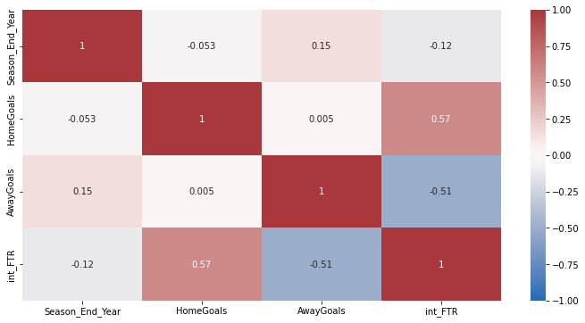

```python
#Creating a correlation with seaborn and matplotlib libraries

corr_matrix = manchester_united_home_games.corr()
plt.figure(figsize=(12,6))
sns.heatmap(corr_matrix, annot=True, vmax = 1, vmin= -1, cmap='vlag')
plt.show()
```

#### Observations

As we can observe, there is a positive correlation between the home goals of Manchester United with the game result. So, here as we can see in the correlation matrix, as its more towards browner side, there's strong relation between Home ground and goals scores meaning, when a team plays on home ground, it is likely to win.

#### Correlation - Game Results and Away ground

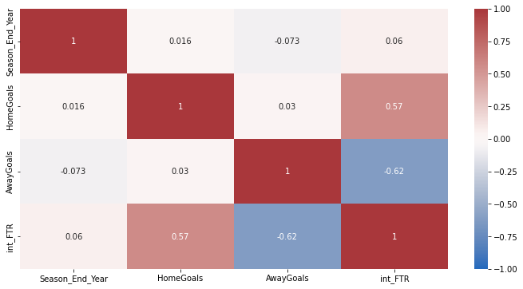

```python
#Creating a correlation with seaborn and matplotlib libraries

corr_matrix_away = manchester_united_away_games.corr()
plt.figure(figsize=(12,6))
sns.heatmap(corr_matrix_away, annot=True, vmax = 1, vmin= -1, cmap='vlag')
plt.show()
```

### Ronaldo's Goals Dataset

```python
# Load dataset

ronaldo_goals_df = pd.read_csv("Ronaldos Goals Dataset.csv")

# Display output printing first 5 rows

ronaldo_goals_df.head()
```

|  | Season | Competition | Matchday | Date | Venue | Club | Opponent | Result | Playing_Position | Minute | At_score | Type | Goal_assist |
| --- | --- | --- | --- | --- | --- | --- | --- | --- | --- | --- | --- | --- | --- |
| 0 | 2-Mar | Liga Portugal | 6 | 10/7/2002 | H | Sporting CP | Moreirense FC | 3:00 | LW | 34 | 2:00 | Solo run | NaN |
| 1 | 2-Mar | Liga Portugal | 6 | 10/7/2002 | H | Sporting CP | Moreirense FC | 3:00 | LW | 90+5 | 3:00 | Header | Rui Jorge |
| 2 | 2-Mar | Liga Portugal | 8 | 10/26/2002 | A | Sporting CP | Boavista FC | 1:02 | NaN | 88 | 1:02 | Right-footed shot | Carlos Martins |
| 3 | 2-Mar | Taca de Portugal Placard | Fourth Round | 11/24/2002 | H | Sporting CP | CD Estarreja | 4:01 | NaN | 67 | 3:00 | Left-footed shot | Cesar Prates |
| 4 | 2-Mar | Taca de Portugal Placard | Fifth Round | 12/18/2002 | H | Sporting CP | FC Oliveira do Hospital | 8:01 | NaN | 13 | 3:00 | NaN | NaN |

In the dataset of "Ronaldos Goals Dataset.csv", we have the stats of each goal Ronaldo has scored in his career. It describes the attributes of the match and the goals.

For example, the name of the competition, opponent, assist provided by, playing position, the time when he scored the goal, etc.

### Data Cleaning & Preparation - Ronaldo's Goals Dataset

- Matchday column states the particular day on which match was played in that competition.
- At_score column mentions the current score after Ronaldo hit a goal.
- Season column is not being used in analysis, therefore we will drop this column.

As Matchday and At_score are not needed for further analysis, we drop both the columns.

#### Dropping columns

```python
# Dropping the columns from the dataset

ronaldo_goals_df = ronaldo_goals_df.drop(columns=['Matchday','At_score', 'Season'], axis=1)


# Display output printing the first 5 rows

ronaldo_goals_df.head()
```

|  | Competition | Date | Venue | Club | Opponent | Result | Playing_Position | Minute | Type | Goal_assist |
| --- | --- | --- | --- | --- | --- | --- | --- | --- | --- | --- |
| 0 | Liga Portugal | 10/7/2002 | H | Sporting CP | Moreirense FC | 3:00 | LW | 34 | Solo run | NaN |
| 1 | Liga Portugal | 10/7/2002 | H | Sporting CP | Moreirense FC | 3:00 | LW | 90+5 | Header | Rui Jorge |
| 2 | Liga Portugal | 10/26/2002 | A | Sporting CP | Boavista FC | 1:02 | NaN | 88 | Right-footed shot | Carlos Martins |
| 3 | Taca de Portugal Placard | 11/24/2002 | H | Sporting CP | CD Estarreja | 4:01 | NaN | 67 | Left-footed shot | Cesar Prates |
| 4 | Taca de Portugal Placard | 12/18/2002 | H | Sporting CP | FC Oliveira do Hospital | 8:01 | NaN | 13 | NaN | NaN |

#### Duplicates

```python
# Check for duplicates in the dataset

ronaldo_dataset_duplicates = ronaldo_goals_df.duplicated().sum()

# Display output

print(f'Number of duplicates in the dataset are:{ronaldo_dataset_duplicates}')
```

```
Number of duplicates in the dataset are:0
```

We did a check for duplicated values in our dataset. When we take the sum of the booleans using the duplicated function, it was found that there are no duplicates in the dataset.

#### Missing values

In the column Playing_Position, we have missing values. Thus, to fill those missing values, we will use fillna function and fill the values with "Other". We used "Other" because we were not sure of Ronaldo's position when he hit that particular goal due to insufficient data.

We also have missing values in Goal_assist column. We will fill those missing values by "Solo goal". If Ronaldo was not assisted by other player to hit the goal, it means he hit the goal himself.

```python
# Fill null values with "Other"

ronaldo_goals_df["Playing_Position"].fillna("Other", inplace = True)
ronaldo_goals_df["Type"].fillna("Other", inplace = True)

# Fill null values with "Solo Goal"

ronaldo_goals_df["Goal_assist"].fillna("Solo Goal", inplace = True)

# Display output printing the first 5 rows

ronaldo_goals_df.head()
```

|  | Competition | Date | Venue | Club | Opponent | Result | Playing_Position | Minute | Type | Goal_assist |
| --- | --- | --- | --- | --- | --- | --- | --- | --- | --- | --- |
| 0 | Liga Portugal | 10/7/2002 | H | Sporting CP | Moreirense FC | 3:00 | LW | 34 | Solo run | Solo Goal |
| 1 | Liga Portugal | 10/7/2002 | H | Sporting CP | Moreirense FC | 3:00 | LW | 90+5 | Header | Rui Jorge |
| 2 | Liga Portugal | 10/26/2002 | A | Sporting CP | Boavista FC | 1:02 | Other | 88 | Right-footed shot | Carlos Martins |
| 3 | Taca de Portugal Placard | 11/24/2002 | H | Sporting CP | CD Estarreja | 4:01 | Other | 67 | Left-footed shot | Cesar Prates |
| 4 | Taca de Portugal Placard | 12/18/2002 | H | Sporting CP | FC Oliveira do Hospital | 8:01 | Other | 13 | Other | Solo Goal |

In the column "Minute", for keeping the data consistent, we removed the discrepencies in data where some extra minutes were added. We used regex to remove the data discrepencies and make it consistent.

```python
# Regex to remove the extra time after first and second half of the match

ronaldo_goals_df['Minute'] = ronaldo_goals_df['Minute'].str.extract('(\d+)')
ronaldo_goals_df.head()
```

|  | Competition | Date | Venue | Club | Opponent | Result | Playing_Position | Minute | Type | Goal_assist |
| --- | --- | --- | --- | --- | --- | --- | --- | --- | --- | --- |
| 0 | Liga Portugal | 10/7/2002 | H | Sporting CP | Moreirense FC | 3:00 | LW | 34 | Solo run | Solo Goal |
| 1 | Liga Portugal | 10/7/2002 | H | Sporting CP | Moreirense FC | 3:00 | LW | 90 | Header | Rui Jorge |
| 2 | Liga Portugal | 10/26/2002 | A | Sporting CP | Boavista FC | 1:02 | Other | 88 | Right-footed shot | Carlos Martins |
| 3 | Taca de Portugal Placard | 11/24/2002 | H | Sporting CP | CD Estarreja | 4:01 | Other | 67 | Left-footed shot | Cesar Prates |
| 4 | Taca de Portugal Placard | 12/18/2002 | H | Sporting CP | FC Oliveira do Hospital | 8:01 | Other | 13 | Other | Solo Goal |

H = Home </br> A = Away

### How has Ronaldo played a significant role in the rise and fall of Manchester United?

In the dataset, the Result column depicts the goals scored by Ronaldo and his the oppponent team depending on Home and Away ground.

For example, considering the datapoint 3:02 in Result column, when Venue column has 'H' meaning the match has been played on home ground, Ronaldo's team has scored 3 goals while his opponent team scored a total of 2 goals. Whereas when Venue is 'A', considering 0:03 datapoint, it means Ronaldo's team scored 3 goals while his opponents scored total 0 goals.

We can observe in the dataset that "Result" column has few data points consisting textual data. To get only scores of teams we will first extract the necessary data using Regular expression and get scores for each team.

```python
#Get numerical values from Result column using Regular expression
#The regular expression below will return digits along with ":"

pattern = '(\d+[:]\d\d)'

# Extract scores of Team 1 and Team 2

ronaldo_goals_df['Result'] = ronaldo_goals_df['Result'].str.extract(pattern)

#Store scores of team 1 and team 2 separately for further analysis

team1_score = ronaldo_goals_df['Result'].str.split(':').str[0]
team2_score = ronaldo_goals_df['Result'].str.split(':').str[1]

# Display output

ronaldo_goals_df.head()
```

|  | Competition | Date | Venue | Club | Opponent | Result | Playing_Position | Minute | Type | Goal_assist |
| --- | --- | --- | --- | --- | --- | --- | --- | --- | --- | --- |
| 0 | Liga Portugal | 10/7/2002 | H | Sporting CP | Moreirense FC | 3:00 | LW | 34 | Solo run | Solo Goal |
| 1 | Liga Portugal | 10/7/2002 | H | Sporting CP | Moreirense FC | 3:00 | LW | 90 | Header | Rui Jorge |
| 2 | Liga Portugal | 10/26/2002 | A | Sporting CP | Boavista FC | 1:02 | Other | 88 | Right-footed shot | Carlos Martins |
| 3 | Taca de Portugal Placard | 11/24/2002 | H | Sporting CP | CD Estarreja | 4:01 | Other | 67 | Left-footed shot | Cesar Prates |
| 4 | Taca de Portugal Placard | 12/18/2002 | H | Sporting CP | FC Oliveira do Hospital | 8:01 | Other | 13 | Other | Solo Goal |

```python
# Converting scores to float for performing arithmetic operations

team1_score = team1_score.astype(float)
team2_score = team2_score.astype(float)
```

#### Analyzing match outcome for Ronaldo's team

To determine which team won we will first calculate the difference between Ronaldo's team and Opponent team. If the value is negative(-) that indicates that Ronaldo's team lost whereas positive value indicates Ronaldo's team won the game.

```python
#Calculate difference of scores between 2 teams and store it in a new column "Team_score_difference"

ronaldo_goals_df['Team_score_difference'] = team1_score - team2_score

#Printing updated dataframe

ronaldo_goals_df.head()
```

|  | Competition | Date | Venue | Club | Opponent | Result | Playing_Position | Minute | Type | Goal_assist | Team_score_difference |
| --- | --- | --- | --- | --- | --- | --- | --- | --- | --- | --- | --- |
| 0 | Liga Portugal | 10/7/2002 | H | Sporting CP | Moreirense FC | 3:00 | LW | 34 | Solo run | Solo Goal | 3.0 |
| 1 | Liga Portugal | 10/7/2002 | H | Sporting CP | Moreirense FC | 3:00 | LW | 90 | Header | Rui Jorge | 3.0 |
| 2 | Liga Portugal | 10/26/2002 | A | Sporting CP | Boavista FC | 1:02 | Other | 88 | Right-footed shot | Carlos Martins | -1.0 |
| 3 | Taca de Portugal Placard | 11/24/2002 | H | Sporting CP | CD Estarreja | 4:01 | Other | 67 | Left-footed shot | Cesar Prates | 3.0 |
| 4 | Taca de Portugal Placard | 12/18/2002 | H | Sporting CP | FC Oliveira do Hospital | 8:01 | Other | 13 | Other | Solo Goal | 7.0 |

```python
# If Venue = 'A', 2nd value after ":" is ronaldo's teams score.
# Therefore to determine the winner we will multiple team_score_difference by -1

ronaldo_goals_df['Team_score_difference'] = np.where(ronaldo_goals_df['Venue'] == 'A' ,ronaldo_goals_df['Team_score_difference'] * -1, ronaldo_goals_df['Team_score_difference'])

#Print Updated Dataframe

ronaldo_goals_df.head()
```

|  | Competition | Date | Venue | Club | Opponent | Result | Playing_Position | Minute | Type | Goal_assist | Team_score_difference |
| --- | --- | --- | --- | --- | --- | --- | --- | --- | --- | --- | --- |
| 0 | Liga Portugal | 10/7/2002 | H | Sporting CP | Moreirense FC | 3:00 | LW | 34 | Solo run | Solo Goal | 3.0 |
| 1 | Liga Portugal | 10/7/2002 | H | Sporting CP | Moreirense FC | 3:00 | LW | 90 | Header | Rui Jorge | 3.0 |
| 2 | Liga Portugal | 10/26/2002 | A | Sporting CP | Boavista FC | 1:02 | Other | 88 | Right-footed shot | Carlos Martins | 1.0 |
| 3 | Taca de Portugal Placard | 11/24/2002 | H | Sporting CP | CD Estarreja | 4:01 | Other | 67 | Left-footed shot | Cesar Prates | 3.0 |
| 4 | Taca de Portugal Placard | 12/18/2002 | H | Sporting CP | FC Oliveira do Hospital | 8:01 | Other | 13 | Other | Solo Goal | 7.0 |

Now that we have all the scores in "Team_score_difference" column we can determine if Ronaldo's team won/lose or was there a tie. To determine Win/Lose/Tie, we will use following process:

1. If Team_score_difference value is greater than 0, it means Ronaldo's Team won
2. If Team_score_difference value is less than 0, it means Ronaldo's Team Lost
3. If Team_score_difference value is equal to 0, it means their was a tie

```python
#Determine Match result - Win/Lose/Tie and store it in a new column "Match Result"

ronaldo_goals_df['Match_result'] = np.where(ronaldo_goals_df['Team_score_difference'] > 0 , 'Win' , np.where((ronaldo_goals_df['Team_score_difference'] != 0) , 'Lose', 'Tie'))

#Print updated data frame

ronaldo_goals_df.head()
```

|  | Competition | Date | Venue | Club | Opponent | Result | Playing_Position | Minute | Type | Goal_assist | Team_score_difference | Match_result |
| --- | --- | --- | --- | --- | --- | --- | --- | --- | --- | --- | --- | --- |
| 0 | Liga Portugal | 10/7/2002 | H | Sporting CP | Moreirense FC | 3:00 | LW | 34 | Solo run | Solo Goal | 3.0 | Win |
| 1 | Liga Portugal | 10/7/2002 | H | Sporting CP | Moreirense FC | 3:00 | LW | 90 | Header | Rui Jorge | 3.0 | Win |
| 2 | Liga Portugal | 10/26/2002 | A | Sporting CP | Boavista FC | 1:02 | Other | 88 | Right-footed shot | Carlos Martins | 1.0 | Win |
| 3 | Taca de Portugal Placard | 11/24/2002 | H | Sporting CP | CD Estarreja | 4:01 | Other | 67 | Left-footed shot | Cesar Prates | 3.0 | Win |
| 4 | Taca de Portugal Placard | 12/18/2002 | H | Sporting CP | FC Oliveira do Hospital | 8:01 | Other | 13 | Other | Solo Goal | 7.0 | Win |

Now that we have Match Result in place, lets Analyze how many times did Manchester United win.

```python
# Get count of number of times Machester United Won and their counts

manchester_united_result_analysis = ronaldo_goals_df[ronaldo_goals_df['Club'] == 'Manchester United']['Match_result'].value_counts()

# Display output

print(manchester_united_result_analysis)
```

```
Win     130
Tie       7
Lose      6
Name: Match_result, dtype: int64
```

#### Conclusion

From this analysis, we've found out that Manchester United has won 90% of the times when Cristiano Ronaldo has scored a goal in the match. This proves the kind of impact he has had on the team.